# Project1

By: Brian Huang, Zachary Fine, Henry Zhao For our project one, we first queried the database for each of the 4 tables, Customers, Items, Orders, and Order_Details. The dataframes for each tables are shown below:

# Data Frames

## Items:

```
##   ITEM_ID                                       TITLE
## 1       1                            Umami In Concert
## 2       2                             Race Car Sounds
## 3       3                       No Rest For The Weary
## 4       4 More Songs About Structures and Comestibles
## 5       5               On The Road With Burt Ruggles
## 6       6                            No Fixed Address
##                  ARTIST UNIT_PRICE
## 1                 Umami         17
## 2         The Ubernerds         13
## 3 No Rest For The Weary         16
## 4 No Rest For The Weary         17
## 5          Burt Ruggles         17
## 6 Sewed the Vest Pocket         16
```

## Customers:

```
##   CUSTOMER_ID CUSTOMER_FIRST_NAME CUSTOMER_LAST_NAME      CUSTOMER_ADDRESS
## 1           1               Korah             Blanca       1555 W Lane Ave
## 2           2                Yash            Randall 11 E Rancho Madera Rd
## 3           3           Johnathon          Millerton        60 Madison Ave
## 4           4             Mikayla             Damion      2021 K Street Nw
## 5           5             Kendall              Mayte 4775 E Miami River Rd
## 6           6             Kaitlin           Hostlery 3250 Spring Grove Ave
##   CUSTOMER_CITY CUSTOMER_STATE CUSTOMER_ZIP CUSTOMER_PHONE CUSTOMER_FAX
## 1      Columbus             OH        43221     6145554432   6145553920
## 2       Madison             WI        53707     2095551205   2095552262
## 3      New York             NY        10010     2125554800         NULL
## 4    Washington             DC        20006     2025555561         NULL
## 5        Cleves             OH        45002     5135553024         NULL
## 6    Cincinnati             OH        45225     8005552128   8005552640
```

## Orders:

```
##   ORDER_ID CUSTOMER_ID          ORDER_DATE        SHIPPED_DATE
## 1       19           1 2012-10-23 00:00:00 2012-10-28 00:00:00
## 2       29           8 2012-11-05 00:00:00 2012-11-11 00:00:00
## 3       32          11 2012-11-10 00:00:00 2012-11-13 00:00:00
## 4       45           2 2012-11-25 00:00:00 2012-11-30 00:00:00
## 5       70          10 2012-12-28 00:00:00 2013-01-07 00:00:00
## 6       89          22 2013-01-20 00:00:00 2013-01-22 00:00:00
```

## Order Details:

```
##   ORDER_ID ITEM_ID ORDER_QTY
## 1      381       1         1
## 2      601       9         1
## 3      442       1         1
## 4      523       9         1
## 5      630       5         1
## 6      778       1         1
```

# Data Frame Plots:

## Items:

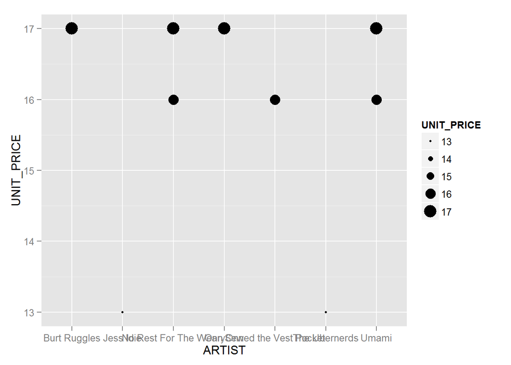

Here, in a graph produced from the “Items” table, we learn that all items are between $13 to $17 with most items being around $17.  
##Customers (# Customers Per State):

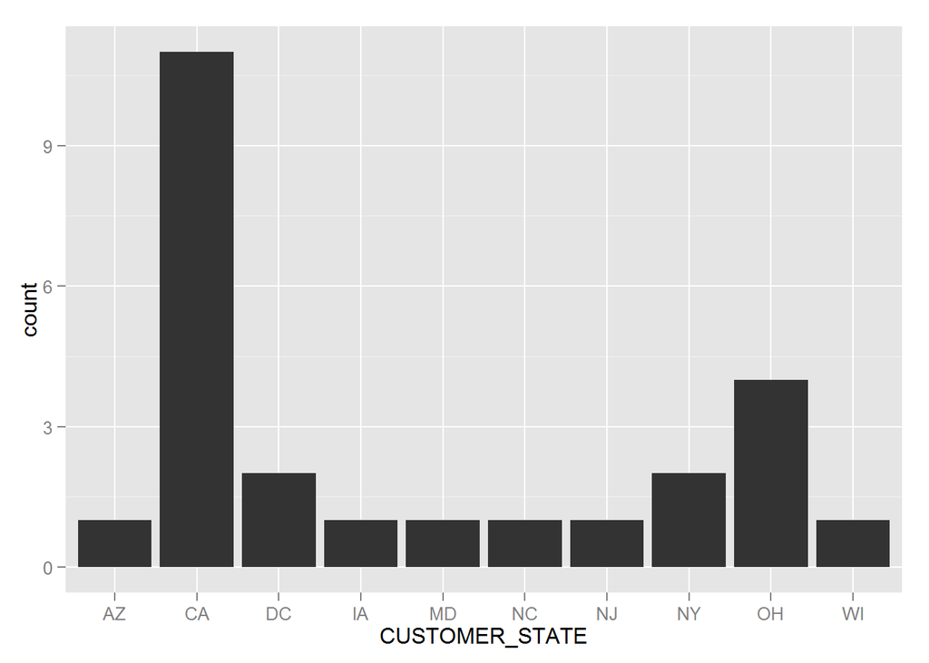

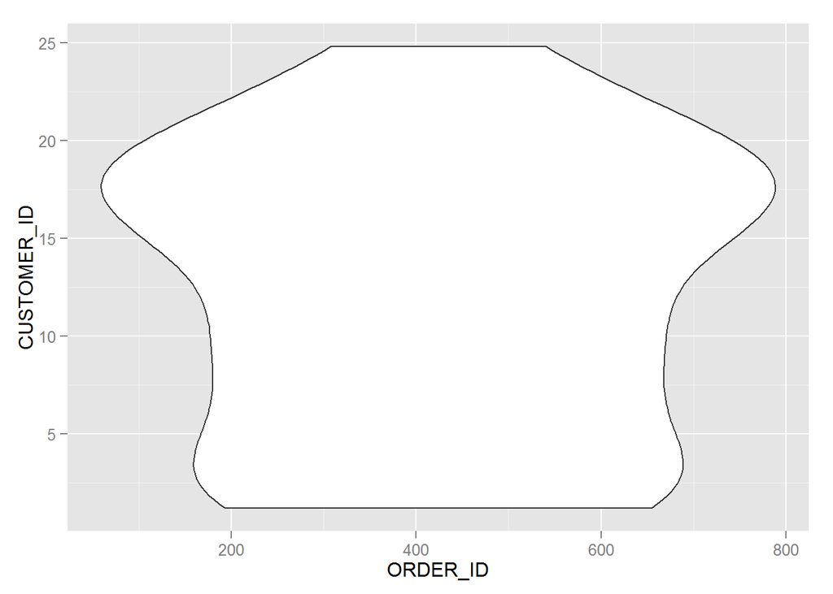

This is a violin graph of order ID vs customer ID. Due to a small number of data points we don’t get much of a visual here, but we can see there is no relation between the two types of ID.  
##Order Details

```
## stat_bin: binwidth defaulted to range/30. Use 'binwidth = x' to adjust this.
```

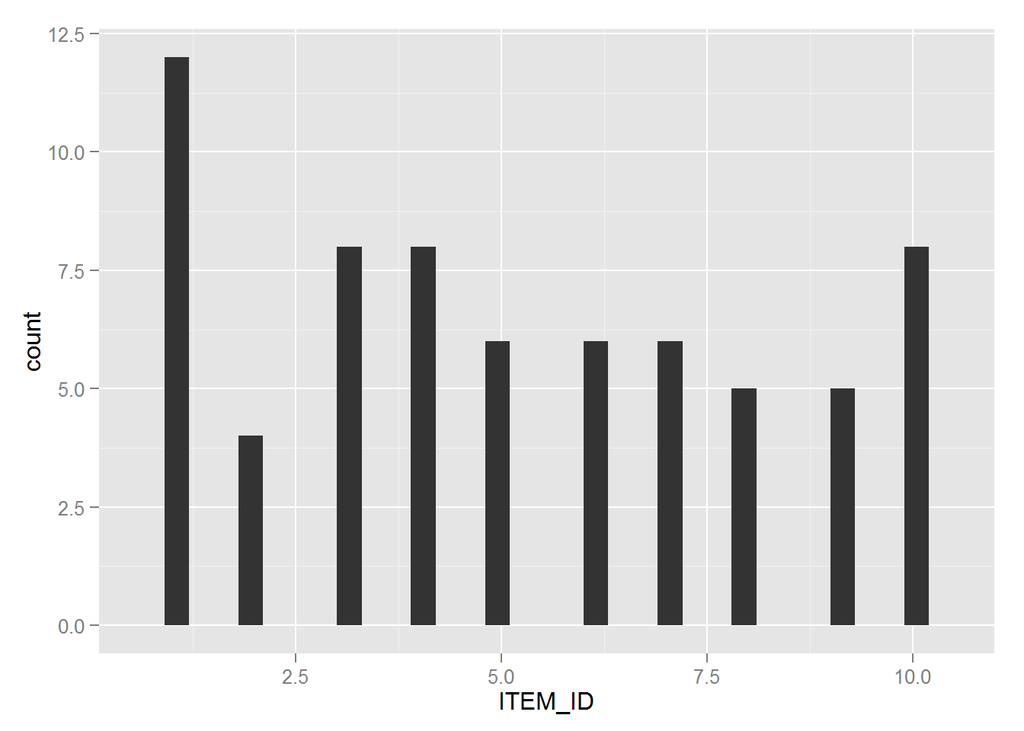

This table of order details shows us which items sold the most and least.  
#Final Plots

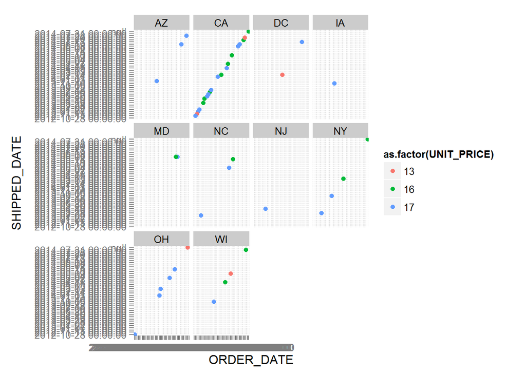

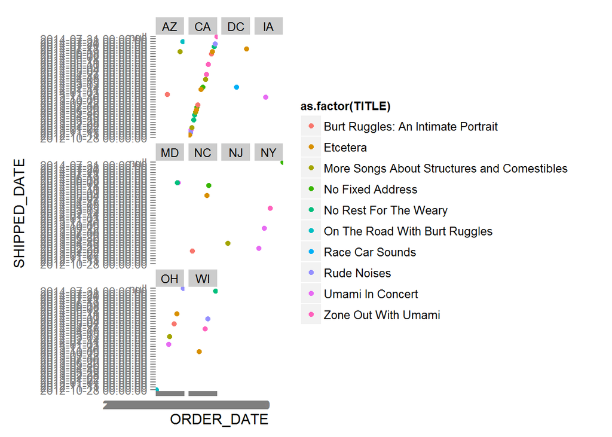

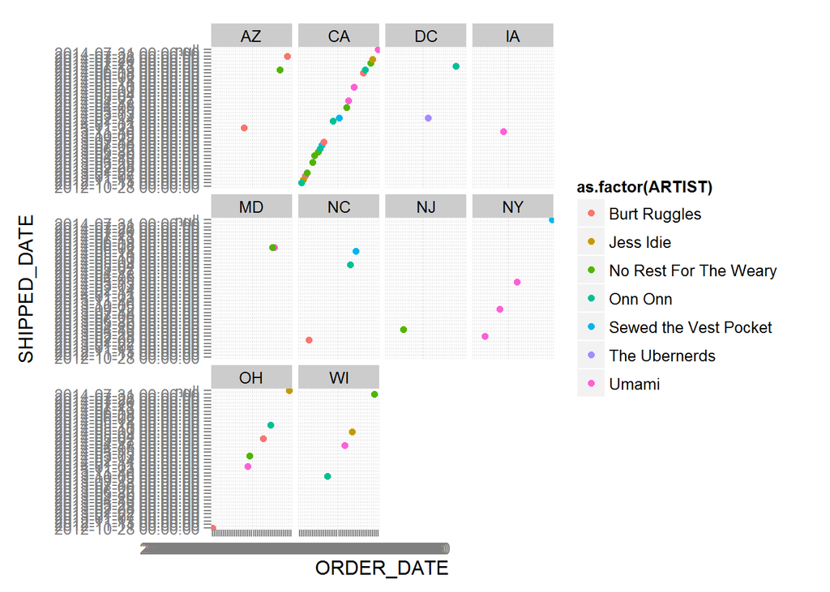

In these plots we can see a strong linear relationship between order date and ship date. Any point that deviates from the linear pattern (too high in the y axis) shows us an anomaly in the time it takes to ship the product. Any order above the line should be investigated for the cause of delayed shipping so the problem can be fixed and customers can remain happy.